# STageR training

Alena van Bömmel

2023-07-18

## Data

- Read the CpG positions within the aDMRs and the corresponding clusters from `clusters.positions.rds`.
- Data matrix with methylation rates of the CpG positions within the aDMRs stored in `methyl.data.rds`

```r
clusters <- readRDS("data/clusters.positions.rds")
data.mat <- readRDS("data/methyl.data.rds")

# age encoded in the sample labels
Age <- colnames(data.mat) %>%
  str_extract("([:digit:])+M")

# 3 age groups
age.gr <- factor(case_when(Age=="3M" ~ 'early',
                          Age=="9M"|Age=="15M" ~ 'mid',
                          Age=="24M"|Age=="28M" ~ 'late'),levels=c('early','mid','late'))
```

## Compute median per cluster

Adds the cluster information to the data matrix and calculates the median value per cluster for each sample.

```r
#reduce the data into cluster values ####
data.clus <- data.mat %>%
  rownames_to_column("co") %>%
  left_join(clusters, by=c("co")) %>%
  group_by(cluster) %>%
  dplyr::summarise(across(starts_with("int"), ~ median(.x, na.rm = TRUE)))

# transposed matrix
data.cl <- data.clus %>%
  pivot_longer(- cluster) %>%
  pivot_wider(names_from = cluster, values_from = value) %>%
  column_to_rownames("name")
```

## STageR using only 3 nonlinear clusters C2, C3 and C4

Trains the final model based on all observations using alpha = 0.5. Plots the coefficient paths based on lambda parameter.

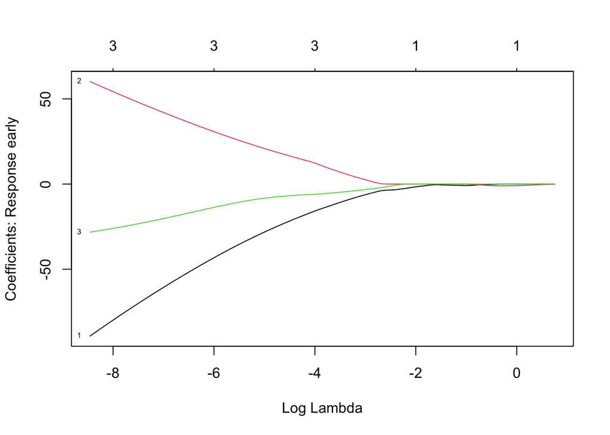

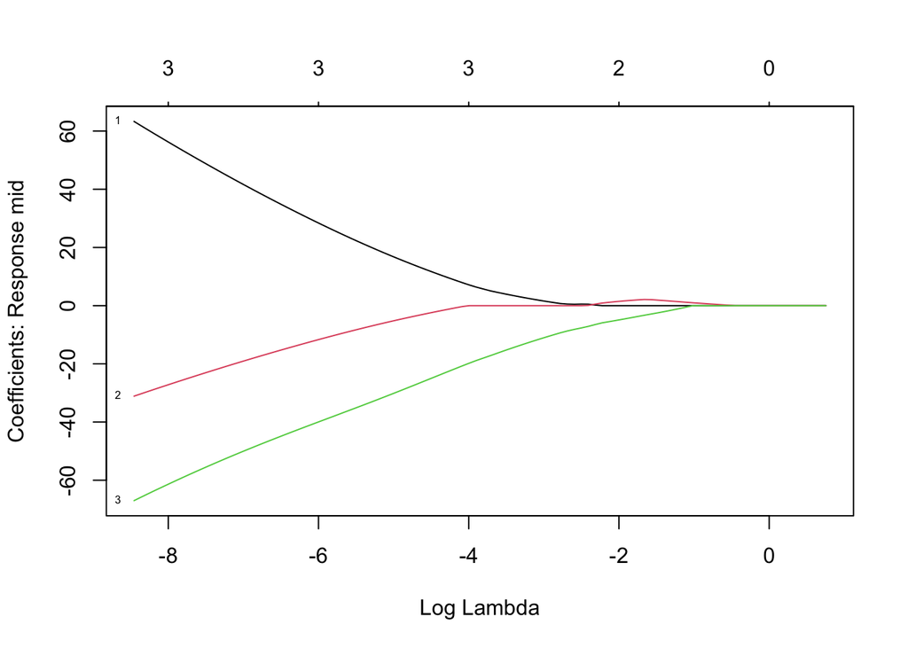

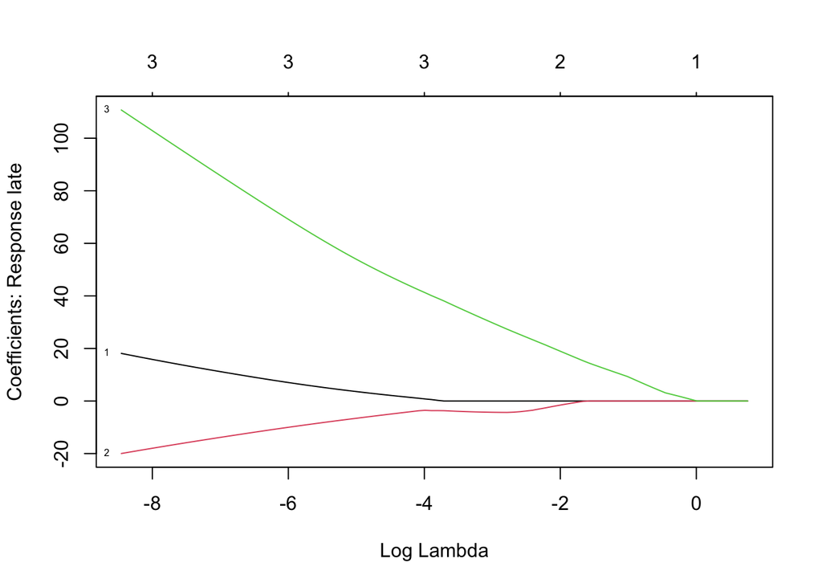

```r
data.model <- data.cl %>%
  dplyr::select(C2, C3, C4)


STageR.final <- cv.glmnet(x=as.matrix(data.model), y=age.gr,
                          family="multinomial",type.measure="class",
                          alpha=0.5,keep=FALSE,intercept=FALSE,
                          type.multinomial="ungrouped", relax=FALSE)

saveRDS(STageR.final, "output/STageR.final.rds")

fit <- glmnet(x=as.matrix(data.model), y=age.gr, family="multinomial",type.measure="class",
                    alpha=0.5,keep=FALSE,intercept=FALSE,type.multinomial="ungrouped")
plot(fit, xvar = "lambda", label = TRUE, type.coef = "coef")
```

## Cross validation (CV)

Functions for cross validation

```r
# cross validation using caret #
set.seed(19)

# create folds equally distributed in age groups
cv.estimation <- function(data, y, fd=10, sd=sample.int(100,size=1), alpha=0.5){
  set.seed(sd)
   sid.early <- createFolds(which(y=="early"), k = fd, list = FALSE, returnTrain = FALSE)
   sid.mid <- createFolds(which(y=="mid"), k = fd, list = FALSE, returnTrain = FALSE)
   sid.late <- createFolds(which(y=="late"), k = fd, list = FALSE, returnTrain = FALSE)

  a <- alpha
  betas.fd <- list()
  results.fd <- list()
  for (i in 1:fd){
    test.id <- sort(c(which(y=="early")[sid.early==i],
                      which(y=="mid")[sid.mid==i],
                      which(y=="late")[sid.late==i]))

    train.x <- data[-test.id,]
    train.y <- y[-test.id]
    cv.fit <- cv.glmnet(x=train.x, y=train.y, family="multinomial",type.measure="class", alpha=a,keep=FALSE,intercept=FALSE)
    fitted <- stats::predict(cv.fit, newx=data[test.id,],s="lambda.min",type="response")
    predicted <- apply(fitted,1, which.max)
    true <- y[test.id]
    results.fd[[i]] <- cbind(predicted,true)
    coefs <- coef(cv.fit, s = "lambda.min")
    betas.fd[[i]] <- sapply(coefs,function(x) as.matrix(x))
  }
  return(list(results.fd,betas.fd))
}

get.misclass <- function(pred, true){
  if (length(pred)!=length(true))
    stop("predicted and true must have the same length!")
  misclass= sum(pred!=true)/length(pred)
  return(misclass)
}
```

10-fold cross validation (CV) for estimation of model parameters is repeated N-times.

The function `cv.estimation` calls the cross validation procedure using balanced sampling in the age groups. It has the following parameters - `fd` = number of folds in the CV - `sd` = seed for random number generation - `alpha` = parameter for elastic net regression

All estimated coefficients from the CV models are saved for plotting. All predictions on the test sets are also saved for plotting.

Final model using all training samples is saved as `output/STageR.final.rds`

```r
# repeat 5 x 10-fold Cross Validation
N <- 5 # how many repeats of the CV
 coefs.early <- c()
 coefs.mid <- c()
 coefs.late <- c()
 me.all <- c()
 results.fd <- list()
for (j in 1:N){
  # fd=how many folds, sd = set the seed, alpha = parameter for elastic net
  cv.res <- cv.estimation(data = as.matrix(data.model), y=age.gr, fd=10, sd=42+10*j, alpha=0.5)
  results.fd <- append(results.fd,cv.res[[1]])
  betas.fd <- cv.res[[2]]
  me.all <- c(me.all, sapply(cv.res[[1]], function(x) get.misclass(x[,1],x[,2])))

  ### convert the format of betas.fd to a list for each age group
  coefs.early <- cbind(coefs.early, sapply(betas.fd, function(x) x[,1]))
  coefs.mid <- cbind(coefs.mid, sapply(betas.fd, function(x) x[,2]))
  coefs.late <- cbind(coefs.late, sapply(betas.fd, function(x) x[,3]))
}

  coefs.all <- list()
  coefs.all[["early"]] <- coefs.early
  coefs.all[["mid"]] <- coefs.mid
  coefs.all[["late"]] <- coefs.late
  rownames(coefs.all[[1]]) <- c("intercept",colnames(data.model))
  rownames(coefs.all[[2]]) <- c("intercept",colnames(data.model))
  rownames(coefs.all[[3]]) <- c("intercept",colnames(data.model))
```

## Plotting the coefficients

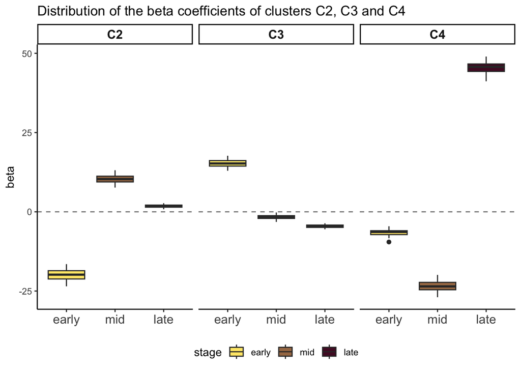

```r
#coefs.all <- readRDS("coefs.all.STageR.final.rds")

  coefs.df <- data.frame()
  for (i in 1:length(coefs.all)){
    coefs.df <- coefs.df %>%
      bind_rows(reshape2::melt(coefs.all[[i]]))
  }
  colnames(coefs.df) <- c("cluster","iteration","beta")
  coefs.df <- coefs.df %>%
    mutate(stage = factor(rep(c("early","mid","late"),each=ncol(coefs.all[[1]])*nrow(coefs.all[[1]])),
                          levels=c("early","mid","late"))) %>%
    dplyr::filter(cluster !="intercept")


   ggplot(coefs.df, aes(x=stage, y=beta, fill=stage))+
    geom_boxplot()+
    geom_hline(yintercept=0,color="grey50",linetype=2)+
    scale_fill_manual(values=pal.age.gr)+
    facet_grid(~ cluster) +
    labs(title = "Distribution of the beta coefficients of clusters C2, C3 and C4") +
    theme_classic()+
    theme(legend.position = "bottom",
          axis.title.x=element_blank(),
          axis.text.x=element_text(size=12, angle=0),
          strip.text.x = element_text(size=12,
                                      face="bold"))
```

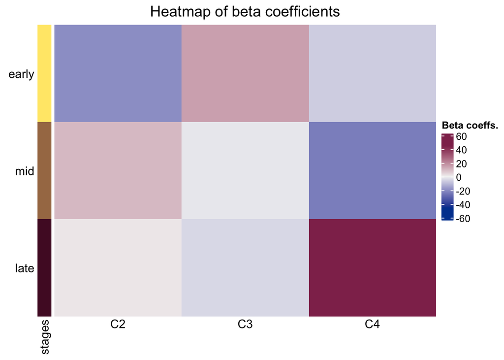

```r
coefs.mat <- as.data.frame(sapply(coefs.all, rowMeans)) %>%
    rownames_to_column("cluster") %>%
    dplyr::filter(cluster!="intercept") %>%
    column_to_rownames("cluster")

# number of Cs in each cluster
no.cs.cluster <- clusters %>%
    dplyr::filter(cluster %in% rownames(coefs.mat)) %>%
    group_by(cluster) %>%
    tally() %>%
    as.data.frame()

ra = rowAnnotation(df=data.frame(stages = colnames(coefs.mat)),
                       col=list(stages=pal.age.gr), show_legend = FALSE)
mx.val <- max(-min(coefs.mat), max(coefs.mat))
col.heatmap <- colorRamp2(c(-mx.val, 0, mx.val), c('#00429e',"#F2F2F2FF",'#90305a'))

Heatmap(t(as.matrix(coefs.mat)),
        name = "Beta coeffs.",
        column_title = "Heatmap of beta coefficients", column_title_gp = gpar(fontsize = 15),
        cluster_columns = F,
        cluster_rows = F,
        col = col.heatmap,
        show_row_names=T, row_names_side = "left",
        left_annotation=ra,
        column_names_gp = gpar(fontsize = 12),
        column_names_rot = 0, column_names_centered = T)
```

## Confusion matrix

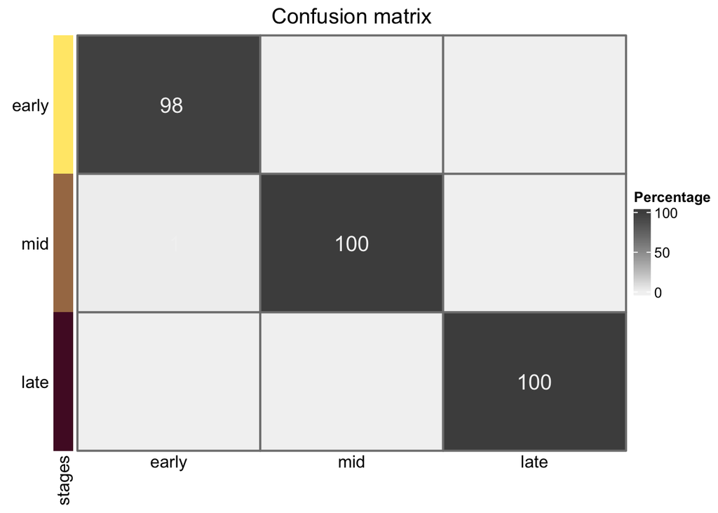

```r
res.cv <- data.frame()
for (i in 1: length(results.fd)){
  res.cv <- rbind(res.cv,results.fd[[i]])
}

conf.mat <- table(res.cv)/colSums(table(res.cv))
colnames(conf.mat) <- c("early","mid","late")
rownames(conf.mat) <- colnames(conf.mat)

ra = rowAnnotation(df=data.frame(stages = rownames(conf.mat)),
                       col=list(stages=pal.age.gr), show_legend = FALSE)
ca = HeatmapAnnotation(df=data.frame(stages = colnames(conf.mat)),
                       col=list(stages=pal.age.gr), show_legend = FALSE)
mx.val <- max(-min(coefs.mat), max(coefs.mat))
col.heatmap <- colorRamp2(c(0, 100), c("#F2F2F2FF","grey30"))

Heatmap(as.matrix(100*conf.mat),
        name = "Percentage",
        column_title = "Confusion matrix", column_title_gp = gpar(fontsize = 15),
        cluster_columns = F, cluster_rows = F,
        col = col.heatmap, rect_gp = gpar(col = "grey50", lwd = 2),
        cell_fun = function(j, i, x, y, width, height, fill) {
        grid.text(sprintf("%3.0f", 100*conf.mat[i, j]),
                  x, y, gp = gpar(fontsize = 15, col="grey95"))},
        show_row_names=T, row_names_side = "left",
        left_annotation=ra,
        column_names_gp = gpar(fontsize = 12),
        column_names_rot = 0, column_names_centered = T)
```

## Heatmap with median methylation values for STageR

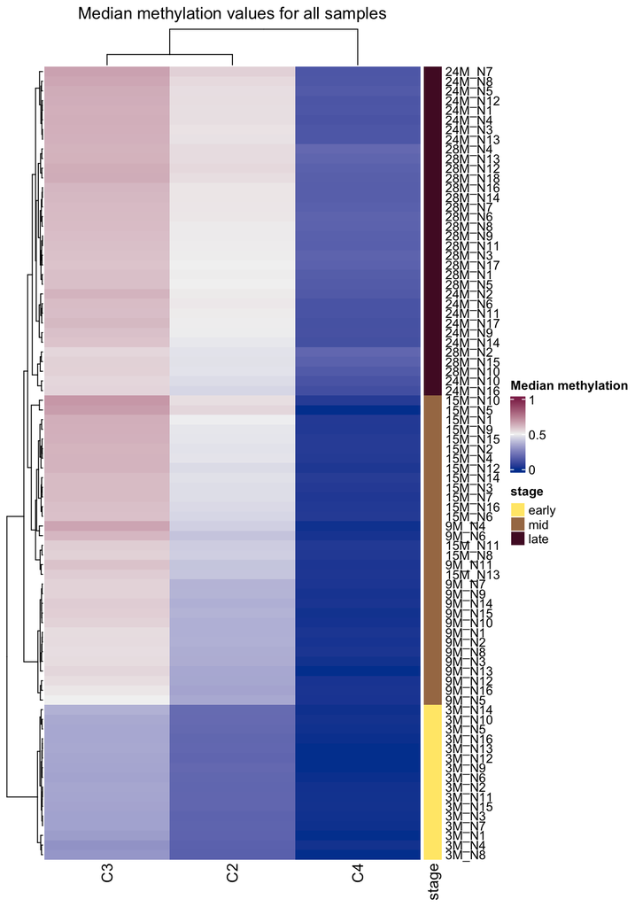

```r
#### methylation values in mean cluters
col.heatmap <- colorRamp2(c(0,0.5,1), c('#00429e',"#F2F2F2FF",'#90305a'))
ra = rowAnnotation(stage=age.gr,
                   col=list(stage=pal.age.gr),
                            show_legend = TRUE)
rownames(data.model) <- gsub("int_","",rownames(data.model))

Heatmap(as.matrix(data.model),
        name = "Median methylation",
        column_title = "Median methylation values for all samples",
        cluster_columns = T,
        cluster_rows = T,
        right_annotation = ra,
        col = col.heatmap,
        show_row_names=T, row_names_side = "right",
        row_names_gp = gpar(fontsize = 10))
```